# Laboratorio sobre discriminación lineal

Jorge de la Vega

26 de octubre de 2018

## Análisis de Datos “German Credit”

### Introducción

En la sesión de hoy, revisaremos un conjunto de datos que se encuentran disponibles de manera pública y que se encuentran relativamente ordenados y “limpios”, para facilitar su análisis y descripción.

En este tutorial, lo que haremos será introducir los paquetes y las estrategias para manipular diferentes tipos de datos.

Los paquetes que utilizaremos son los siguientes:

```r
library(dplyr)   #Para manipular fácilmente los datos en general
library(tidyverse)
library(forcats) #Para manejo de variables categóricas
library(MASS)    #Función lda y qda
```

### Preparación de los Datos

Los datos que se considerarán en este ejercicio corresponden a 1000 casos de personas con varios de atributos demográficos y financieros (edad, estado civil, ingreso, etc) a las que se les clasifica como buenos o malos pagadores cuando se les otorgó un crédito por parte de un Banco alemán.

**Estos datos se pueden usar para probar modelos de riesgos, o credit scoring y medir qué tan bien pueden predecir esos modelos con los atributos dados para cada persona.**

Los datos se encuentran en el Repositorio UCI de la Universidad de California, que tiene varios conjuntos de datos que se pueden usar para analizar y probar diferentes tipos de modelos para Aprendizaje de Máquina.

```r
# https://archive.ics.uci.edu/ml/machine-learning-databases/statlog/german/german.data
german <- read.table(file = "../data/german.data",
                     header = F,
                     sep = "")
```

Hay 1,000 observaciones en el conjunto de datos, con 21 variables y 8 de ellas son variables discretas, 13 son factores; la mayoría de los datos están codificados y para entenderlos hay que revisar el diccionario de datos.

Los datos están dados sin nombres de columnas, hay que tomarlos de la descripción de los datos. Entonces hay que ponerle nombres a las columnas. Estas tienen la siguiente información: 1. Estatus de la cuenta de cheques existente. 2. Duración (en meses). 3. Historial de crédito 4.Propósito del crédito. 5. Monto del crédito. 6. Cuenta de ahorros/bonos. 7. Tiempo en el empleo actual. 8. Tasa en porcentaje de ingreso disponible. 9. Estatus personal y sexo. 10. Otros deudores/garantores. 11. Tiempo en la residencia actual. 12. Propietario. 13. Edad en años. 14. Otros planes de entrega. 15. Casa 16. Número de créditos existentes en este banco. 17. Empleo. 18. Número de dependientes económicos. 19. Tiene teléfono. 20. Es extranjero?. 21. Pago el crédito (si=1,no=2)

```r
colnames(german) = c("cta_cheques", "duracion", "his_credito", "proposito", "monto",
                     "cta_ahorro", "empleo_act", "tasa_pagos", "status_personal", "otros_deudores",
                     "resid_act", "propiedad", "edad", "otros_pagos", "casa", "no_creditos",
                     "tipo_trabajo", "num_depen", "telefono", "extranjero", "tipo")
head(german)
```

```
##   cta_cheques duracion his_credito proposito monto cta_ahorro empleo_act tasa_pagos status_personal
## 1         A11        6         A34       A43  1169        A65        A75          4             A93
## 2         A12       48         A32       A43  5951        A61        A73          2             A92
## 3         A14       12         A34       A46  2096        A61        A74          2             A93
## 4         A11       42         A32       A42  7882        A61        A74          2             A93
## 5         A11       24         A33       A40  4870        A61        A73          3             A93
## 6         A14       36         A32       A46  9055        A65        A73          2             A93
##   otros_deudores resid_act propiedad edad otros_pagos casa no_creditos tipo_trabajo num_depen
## 1           A101         4      A121   67        A143 A152           2         A173         1
## 2           A101         2      A121   22        A143 A152           1         A173         1
## 3           A101         3      A121   49        A143 A152           1         A172         2
## 4           A103         4      A122   45        A143 A153           1         A173         2
## 5           A101         4      A124   53        A143 A153           2         A173         2
## 6           A101         4      A124   35        A143 A153           1         A172         2
##   telefono extranjero tipo
## 1     A192       A201    1
## 2     A191       A201    2
## 3     A191       A201    1
## 4     A191       A201    1
## 5     A191       A201    2
## 6     A192       A201    1
```

```r
glimpse(german)  #Para dar un vistazo a la estructura, también se puede usar str(german)
```

```
## Observations: 1,000
## Variables: 21
## $ cta_cheques     <fct> A11, A12, A14, A11, A11, A14, A14, A12, A14, A12, A12, A11, A12, A11, A11…
## $ duracion        <int> 6, 48, 12, 42, 24, 36, 24, 36, 12, 30, 12, 48, 12, 24, 15, 24, 24, 30, 24…
## $ his_credito     <fct> A34, A32, A34, A32, A33, A32, A32, A32, A32, A34, A32, A32, A32, A34, A32…
## $ proposito       <fct> A43, A43, A46, A42, A40, A46, A42, A41, A43, A40, A40, A49, A43, A40, A40…
## $ monto           <int> 1169, 5951, 2096, 7882, 4870, 9055, 2835, 6948, 3059, 5234, 1295, 4308, 1…
## $ cta_ahorro      <fct> A65, A61, A61, A61, A61, A65, A63, A61, A64, A61, A61, A61, A61, A61, A61…
## $ empleo_act      <fct> A75, A73, A74, A74, A73, A73, A75, A73, A74, A71, A72, A72, A73, A75, A73…
## $ tasa_pagos      <int> 4, 2, 2, 2, 3, 2, 3, 2, 2, 4, 3, 3, 1, 4, 2, 4, 4, 2, 4, 3, 4, 2, 1, 3, 2…
## $ status_personal <fct> A93, A92, A93, A93, A93, A93, A93, A93, A91, A94, A92, A92, A92, A93, A92…
## $ otros_deudores  <fct> A101, A101, A101, A103, A101, A101, A101, A101, A101, A101, A101, A101, A…
## $ resid_act       <int> 4, 2, 3, 4, 4, 4, 4, 2, 4, 2, 1, 4, 1, 4, 4, 2, 4, 3, 2, 2, 4, 3, 3, 4, 1…
## $ propiedad       <fct> A121, A121, A121, A122, A124, A124, A122, A123, A121, A123, A123, A122, A…
## $ edad            <int> 67, 22, 49, 45, 53, 35, 53, 35, 61, 28, 25, 24, 22, 60, 28, 32, 53, 25, 4…
## $ otros_pagos     <fct> A143, A143, A143, A143, A143, A143, A143, A143, A143, A143, A143, A143, A…
## $ casa            <fct> A152, A152, A152, A153, A153, A153, A152, A151, A152, A152, A151, A151, A…
## $ no_creditos     <int> 2, 1, 1, 1, 2, 1, 1, 1, 1, 2, 1, 1, 1, 2, 1, 1, 2, 3, 1, 1, 3, 1, 2, 1, 2…
## $ tipo_trabajo    <fct> A173, A173, A172, A173, A173, A172, A173, A174, A172, A174, A173, A173, A…
## $ num_depen       <int> 1, 1, 2, 2, 2, 2, 1, 1, 1, 1, 1, 1, 1, 1, 1, 1, 1, 1, 1, 2, 1, 2, 2, 1, 1…
## $ telefono        <fct> A192, A191, A191, A191, A191, A192, A191, A192, A191, A191, A191, A191, A…
## $ extranjero      <fct> A201, A201, A201, A201, A201, A201, A201, A201, A201, A201, A201, A201, A…
## $ tipo            <int> 1, 2, 1, 1, 2, 1, 1, 1, 1, 2, 2, 2, 1, 2, 1, 2, 1, 1, 2, 1, 1, 1, 1, 1, 1…
```

Como se tienen los datos originales, son poco interpretables como están y hay que revisar qué significa cada código asociado a las variables categóricas en la documentación provista, así que será conveniente “domesticar” a los datos para poder extraer información de ellos y poder describir a la muestra adecuadamente.

```r
# Recodificación de los factores (de acuerdo al diccionario de datos)
german1 <- german %>% mutate(cta_cheques = fct_recode(cta_cheques,
                                                      nada = "A11",
                                                      menos_200 = "A12",
                                                      mas_200 = "A13",
                                                      no_cuenta = "A14"),
                             duracion = duracion,
                             his_credito = fct_recode(his_credito,
                                                      cred_pagados = "A30",
                                                      cred_local_pagados = "A31",
                                                      otros_cred_pagados = "A32",
                                                      retraso_pagos = "A33",
                                                      cuenta_critica = "A34"),
                             proposito = fct_recode(proposito,
                                                    auto_nuevo = "A40",
                                                    auto_usado = "A41",
                                                    muebles = "A42",
                                                    electro = "A43",
                                                    enseres = "A44",
                                                    reparaciones = "A45",
                                                    educacion = "A46",
                                                    vacacion = "A47",
                                                    capacitacion = "A48",
                                                    negocios = "A49",
                                                    otros = "A410"),
                             monto = monto,
                             cta_ahorro = fct_recode(cta_ahorro,
                                                     menos_100 = "A61",
                                                     entre_100_500 = "A62",
                                                     entre_500_1000 = "A63",
                                                     mas_1000 = "A64",
                                                     nocuenta = "A65"),
                             empleo_act = fct_recode(empleo_act,
                                                     desempleado = "A71",
                                                     menos_1 = "A72",
                                                     entre_1_4 = "A73",
                                                     entre_4_7 = "A74",
                                                     mas_7 = "A75"),
                             tasa_pagos = tasa_pagos,
                             status_personal = fct_recode(status_personal,
                                                          h_divor = "A91",
                                                          m_divor_sep_cas = "A92",
                                                          h_sol = "A93",
                                                          h_casado_viudo = "A94",
                                                          m_sol = "A95"),
                             otros_deudores = fct_recode(otros_deudores,
                                                         ninguno = "A101",
                                                         coaplicante = "A102",
                                                         aval="A103"),
                             propiedad = fct_recode(propiedad,
                                                    bienes_raices = "A121",
                                                    seguro = "A122",
                                                    auto_otro_no6 = "A123",
                                                    no_sin_prop = "A124"),
                             edad = edad,
                             otros_pagos = fct_recode(otros_pagos,
                                                      banco = "A141",
                                                      tiendas = "A142",
                                                      ninguno = "A143"),
                             casa = fct_recode(casa,
                                               renta = "A151",
                                               propia = "A152",
                                               gratis = "A153"),
                             no_creditos = no_creditos,
                             tipo_trabajo = fct_recode(tipo_trabajo,
                                                       desempleado = "A171",
                                                       incapacitado_residente = "A172",
                                                       empleado_capacitado = "A173",
                                                       empleado_prof = "A174"),
                             num_depen = num_depen,
                             telefono = fct_recode(telefono,
                                                   ninguno = "A191",
                                                   si = "A192"),
                             extranjero = fct_recode(extranjero,
                                                     si = "A201",
                                                     no = "A202"),
                             tipo = ifelse(tipo == 2, 0, 1) )
head(german1)
```

```
##   cta_cheques duracion        his_credito  proposito monto cta_ahorro empleo_act tasa_pagos
## 1        nada        6     cuenta_critica    electro  1169   nocuenta      mas_7          4
## 2   menos_200       48 otros_cred_pagados    electro  5951  menos_100  entre_1_4          2
## 3   no_cuenta       12     cuenta_critica  educacion  2096  menos_100  entre_4_7          2
## 4        nada       42 otros_cred_pagados    muebles  7882  menos_100  entre_4_7          2
## 5        nada       24      retraso_pagos auto_nuevo  4870  menos_100  entre_1_4          3
## 6   no_cuenta       36 otros_cred_pagados  educacion  9055   nocuenta  entre_1_4          2
##   status_personal otros_deudores resid_act     propiedad edad otros_pagos   casa no_creditos
## 1           h_sol        ninguno         4 bienes_raices   67     ninguno propia           2
## 2 m_divor_sep_cas        ninguno         2 bienes_raices   22     ninguno propia           1
## 3           h_sol        ninguno         3 bienes_raices   49     ninguno propia           1
## 4           h_sol           aval         4        seguro   45     ninguno gratis           1
## 5           h_sol        ninguno         4   no_sin_prop   53     ninguno gratis           2
## 6           h_sol        ninguno         4   no_sin_prop   35     ninguno gratis           1
##             tipo_trabajo num_depen telefono extranjero tipo
## 1    empleado_capacitado         1       si         si    1
## 2    empleado_capacitado         1  ninguno         si    0
## 3 incapacitado_residente         2  ninguno         si    1
## 4    empleado_capacitado         2  ninguno         si    1
## 5    empleado_capacitado         2  ninguno         si    0
## 6 incapacitado_residente         2       si         si    1
```

`tabla`contiene todas las tablas de contingencia de las variables categoricas.

```r
tabla <- with(german1, table(cta_cheques,
                             his_credito,
                             proposito,
                             cta_ahorro,
                             empleo_act,
                             status_personal,
                             otros_deudores,
                             propiedad,
                             otros_pagos,
                             casa,
                             tipo_trabajo,
                             telefono,
                             extranjero,
                             tipo))
dim(tabla)
```

```
##  [1]  4  5 10  5  5  4  3  4  3  3  4  2  2  2
```

```r
prod(dim(tabla)) #número de celdas
```

```
## [1] 69120000
```

Noten que el número de dimensiones de esta tabla es muy grande, por lo que posiblemente haya muchos conteos cero. Una manera de resolver este problema es reducir el número de categorías en las variables categóricas agrupando las categorías que tienen pocos conteos.

A continuación se calculan las proporciones para cada una de las variables categóricas

```r
for (i in 1:14) print(margin.table( prop.table(tabla), i))
```

```
## cta_cheques
##      nada menos_200   mas_200 no_cuenta
##     0.274     0.269     0.063     0.394
## his_credito
##       cred_pagados cred_local_pagados otros_cred_pagados      retraso_pagos     cuenta_critica
##              0.040              0.049              0.530              0.088              0.293
## proposito
##   auto_nuevo   auto_usado        otros      muebles      electro      enseres reparaciones
##        0.234        0.103        0.012        0.181        0.280        0.012        0.022
##    educacion capacitacion     negocios
##        0.050        0.009        0.097
## cta_ahorro
##      menos_100  entre_100_500 entre_500_1000       mas_1000       nocuenta
##          0.603          0.103          0.063          0.048          0.183
## empleo_act
## desempleado     menos_1   entre_1_4   entre_4_7       mas_7
##       0.062       0.172       0.339       0.174       0.253
## status_personal
##         h_divor m_divor_sep_cas           h_sol  h_casado_viudo
##           0.050           0.310           0.548           0.092
## otros_deudores
##     ninguno coaplicante        aval
##       0.907       0.041       0.052
## propiedad
## bienes_raices        seguro auto_otro_no6   no_sin_prop
##         0.282         0.232         0.332         0.154
## otros_pagos
##   banco tiendas ninguno
##   0.139   0.047   0.814
## casa
##  renta propia gratis
##  0.179  0.713  0.108
## tipo_trabajo
##            desempleado incapacitado_residente    empleado_capacitado          empleado_prof
##                  0.022                  0.200                  0.630                  0.148
## telefono
## ninguno      si
##   0.596   0.404
## extranjero
##    si    no
## 0.963 0.037
## tipo
##   0   1
## 0.3 0.7
```

Notemos lo siguiente:

- En `cta_cheques` sólo hay unos cuantos clientes con más de 200 DM. Podemos considerar niveles `no_cuenta`, `no_saldo` y `saldo`.

```r
german1 <- german1 %>% mutate(cta_cheques = fct_collapse(cta_cheques, nocuenta = "no_cuenta",
                                                                      no_saldo = "nada",
                                                                      saldo    = c("menos_200","mas_200")))
```

- Para el `hist_credito` podemos agrupar en tres categorías: pagados, retrasados, criticos

```r
german1 <- german1 %>% mutate(his_credito = fct_collapse(his_credito, retrasados = "retraso_pagos",
                                                                      criticos = "cuenta_critica",
                                                                      pagados = c("cred_pagados", "cred_local_pagados", "otros_cred_pagados")))
```

- Para el proposito del crédito, podemos agrupar {educacion, capacitación} en una categoria, y {enseres, muebles, electro, reparaciones} en otra e incorporar negocios en otros:

```r
german1 <- german1 %>% mutate(proposito = fct_collapse(proposito, otros = c("otros","negocios"),
                                                       hogar = c("muebles", "enseres", "electro", "reparaciones"),
                                                                educacion = c("educacion", "capacitacion")))
```

- La `cuenta_ahorro` se puede agrupar en `nocuenta`,`menos_100`, `de100a1000` y `mas_de_1000`.

```r
german1 <- german1 %>% mutate(cta_ahorro = fct_collapse(cta_ahorro, nocuenta = "nocuenta",
                                                       menos_100 = "menos_100",
                                                       mas_1000 = "mas_1000",
                                                       de100a1000 = c("entre_100_500","entre_500_1000")))
```

- En `empleo_act` podemos considerar a los desempleados en la categoría de personas que tienen menos de un año trabajando

```r
german1 <- german1 %>% mutate(empleo_act = fct_collapse(empleo_act, menos_1 = c("desempleado","menos_1"),
                                                       entre_1_4 = "entre_1_4",
                                                       entre_4_7 = "entre_4_7",
                                                       mas_7 = "mas_7"))
```

- A los hombres divorciados los podemos meter con los solteros:

```r
german1 <- german1 %>% mutate(status_personal = fct_collapse(status_personal,
                                                       h_div_sol = c("h_divor","h_sol"),
                                                       h_cas_viud = "h_casado_viudo",
                                                       m_div_sep_cas = "m_divor_sep_cas"))
```

- Podemos agrupar a otros deudores como ninguno o alguno

```r
german1 <- german1 %>% mutate(otros_deudores = fct_collapse(otros_deudores,
                                                       ninguno = "ninguno",
                                                       alguno = c("coaplicante","aval")))
```

- A los desempleados los podemos juntar con los incapacitados y poner dos niveles: no trabaja, trabaja

```r
german1 <- german1 %>% mutate(tipo_trabajo = fct_collapse(tipo_trabajo,
                                                       no_trabaja = c("desempleado","incapacitado_residente"),
                                                       alguno = c("empleado_capacitado","empleado_prof")))
```

Podemos recalcular las tablas de contingencia después de las transformaciones:

```r
tabla <- with(german1, table(cta_cheques,
                             his_credito,
                             proposito,
                             cta_ahorro,
                             empleo_act,
                             status_personal,
                             otros_deudores,
                             propiedad,
                             otros_pagos,
                             casa,
                             tipo_trabajo,
                             telefono,
                             extranjero,
                             tipo))
dim(tabla)
```

```
##  [1] 3 3 5 4 4 3 2 4 3 3 2 2 2 2
```

```r
prod(dim(tabla)) #número de celdas
```

```
## [1] 2488320
```

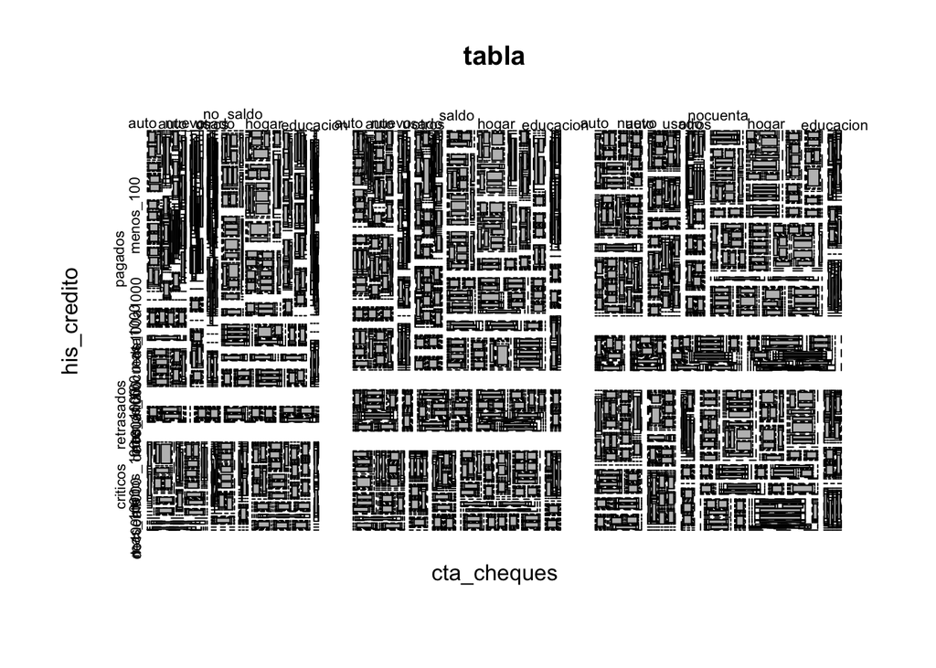

```r
mosaicplot(tabla) #vista de las 2,488,320 celdas
```

Aún parecen ser muchas dimensiones. También calculamos las tablas de contingencia ajustadas:

```r
for (i in 1:14) print(margin.table( prop.table(tabla), i))
```

```
## cta_cheques
## no_saldo    saldo nocuenta
##    0.274    0.332    0.394
## his_credito
##    pagados retrasados   criticos
##      0.619      0.088      0.293
## proposito
## auto_nuevo auto_usado      otros      hogar  educacion
##      0.234      0.103      0.109      0.495      0.059
## cta_ahorro
##  menos_100 de100a1000   mas_1000   nocuenta
##      0.603      0.166      0.048      0.183
## empleo_act
##   menos_1 entre_1_4 entre_4_7     mas_7
##     0.234     0.339     0.174     0.253
## status_personal
##     h_div_sol m_div_sep_cas    h_cas_viud
##         0.598         0.310         0.092
## otros_deudores
## ninguno  alguno
##   0.907   0.093
## propiedad
## bienes_raices        seguro auto_otro_no6   no_sin_prop
##         0.282         0.232         0.332         0.154
## otros_pagos
##   banco tiendas ninguno
##   0.139   0.047   0.814
## casa
##  renta propia gratis
##  0.179  0.713  0.108
## tipo_trabajo
## no_trabaja     alguno
##      0.222      0.778
## telefono
## ninguno      si
##   0.596   0.404
## extranjero
##    si    no
## 0.963 0.037
## tipo
##   0   1
## 0.3 0.7
```

### Análisis descriptivo

A continuación hay varias preguntas que se podrían formular para guiar un análisis exploratorio:

```r
margin.table(prop.table(tabla),c(1,14))
```

```
##            tipo
## cta_cheques     0     1
##    no_saldo 0.135 0.139
##    saldo    0.119 0.213
##    nocuenta 0.046 0.348
```

- El empleo actual

```r
margin.table(prop.table(tabla),c(5,14))
```

```
##            tipo
## empleo_act      0     1
##   menos_1   0.093 0.141
##   entre_1_4 0.104 0.235
##   entre_4_7 0.039 0.135
##   mas_7     0.064 0.189
```

- el tipo de trabajo?

```r
margin.table(prop.table(tabla),c(11,14))
```

```
##             tipo
## tipo_trabajo     0     1
##   no_trabaja 0.063 0.159
##   alguno     0.237 0.541
```

- el status personal?, ¿hombre o mujer?

```r
margin.table(prop.table(tabla),c(6,14))
```

```
##                tipo
## status_personal     0     1
##   h_div_sol     0.166 0.432
##   m_div_sep_cas 0.109 0.201
##   h_cas_viud    0.025 0.067
```

- propósito del préstamo?

```r
margin.table(prop.table(tabla),c(3,14))
```

```
##             tipo
## proposito        0     1
##   auto_nuevo 0.089 0.145
##   auto_usado 0.017 0.086
##   otros      0.039 0.070
##   hogar      0.132 0.363
##   educacion  0.023 0.036
```

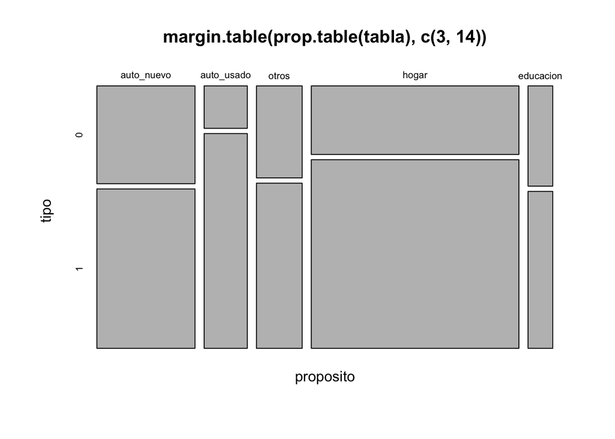

```r
mosaicplot(margin.table(prop.table(tabla),c(3,14)))
```

3. ¿Cuál es la distribución de las edades, condicional a la calificación de crédito?

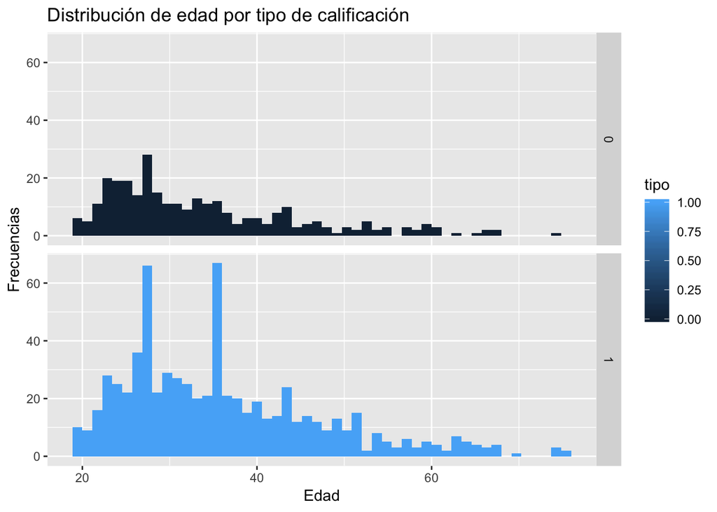

```r
ggplot(data = german1, aes(edad, geom = "density", fill = tipo)) +
  geom_histogram(bins = 50) +
  facet_grid(tipo ~ .) +
  labs(title="Distribución de edad por tipo de calificación",
       y = "Frecuencias",
       x = "Edad")
```

En los hisogramas no se ven diferencias significativas en la distribución de edad condicional a la calificación crediticia

4. ¿Cuál es la distribución de los montos de crédito?

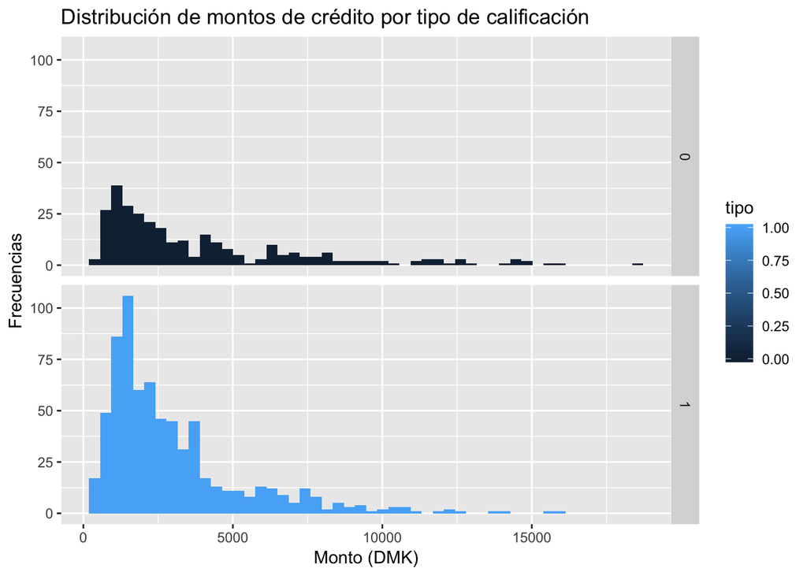

```r
ggplot(data = german1, aes(monto, geom = "density", fill = tipo)) +
  geom_histogram(bins = 50) +
  facet_grid(tipo ~ .) +
  labs(title="Distribución de montos de crédito por tipo de calificación",
       y = "Frecuencias",
       x = "Monto (DMK)")
```

En las gráficas anteriores se puede ver claramente que las distribuciones del monto tienen un sesgo a la derecha, concentrando la mayor parte de los créditos en montos bajos. Con la finalidad de aproximar los datos a normalidad, se puede aplicar una transformación, se puede considerar el logaritmo. Lo mismo sucede con las gráficas de edad y duración.

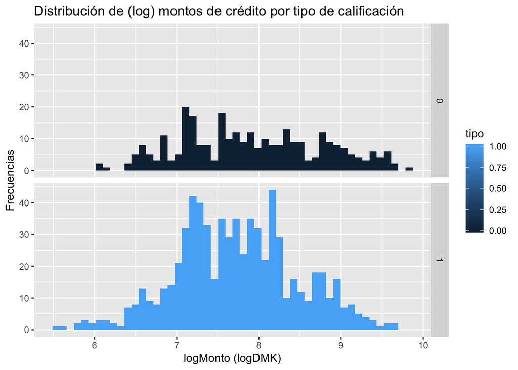

```r
german1 <- german1 %>% mutate(logmonto = log(monto),
                              logedad = log(edad),
                              logduracion = log(duracion))
ggplot(data = german1, aes(logmonto, geom = "density", fill = tipo)) +
  geom_histogram(bins = 50) +
  facet_grid(tipo ~ .) +
  labs(title="Distribución de (log) montos de crédito por tipo de calificación",
       y = "Frecuencias",
       x = "logMonto (logDMK)")
```

5. ¿Cuál es la relación entre el monto de crédito y la edad? ¿Tiene relación con el propósito del crédito?

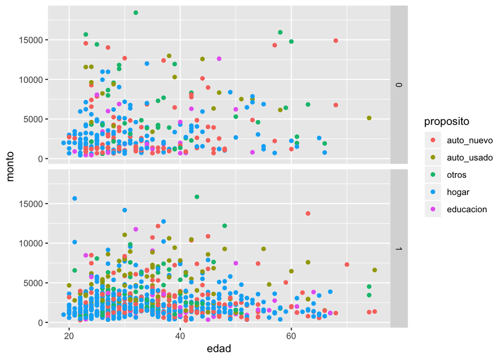

```r
ggplot(data=german1,aes(edad, monto, geom="point")) +
  geom_point(aes(color=proposito)) +
  facet_grid(tipo ~ .)
```

En la gráfica anterior se puede ver usualmente los clientes que no pagan los créditos con mayor frecuencia tienden a ser con frecuencia más jóvenes, aunque en general son más jóvenes los que solicitan créditos en general. No se percibe una clara asociación entre el propósito del crédito y la edad.

### Análisis discriminante básico.

Para modelar LDA usaremos sólo las variables que podrían ser consideradas continuas: `duracion`, `monto` y `edad`, y posiblemente `tasa_pagos`, aunque esta variable sólo toma cuatro valores. Como ya vimos, transformamos las variables a logaritmos para aproximarnos mejor a normalidad.

Con variables indicadoras, los supuestos de distribución normal son muy débiles, y no serán consideradas aquí. Sin embargo, las utilizaremos más adelante en regresión logística y en otros modelos no paramétricos. Tamabien podríamos probablemente incluir variables de caracter ordinal asignando una escala de valores.

```r
cred <- german1 %>%
        dplyr::select(logduracion, logmonto, logedad, tasa_pagos, tipo) %>%
        mutate(tipo = factor(tipo))
summary(cred)
```

```
##   logduracion       logmonto        logedad        tasa_pagos    tipo
##  Min.   :1.386   Min.   :5.521   Min.   :2.944   Min.   :1.000   0:300
##  1st Qu.:2.485   1st Qu.:7.219   1st Qu.:3.296   1st Qu.:2.000   1:700
##  Median :2.890   Median :7.749   Median :3.497   Median :3.000
##  Mean   :2.877   Mean   :7.789   Mean   :3.524   Mean   :2.973
##  3rd Qu.:3.178   3rd Qu.:8.287   3rd Qu.:3.738   3rd Qu.:4.000
##  Max.   :4.277   Max.   :9.821   Max.   :4.317   Max.   :4.000
```

```r
cred <- data.frame(cred)
```

A continuación se ajusta el modelo lineal discriminante, utilizando como distribución inicial las proporciones de cada clase.

```r
lda_lineal <- lda(tipo ~ ., data=cred) #por default usa las probabilidades iniciales de las clases.
lda_lineal
```

```
## Call:
## lda(tipo ~ ., data = cred)
##
## Prior probabilities of groups:
##   0   1
## 0.3 0.7
##
## Group means:
##   logduracion logmonto  logedad tasa_pagos
## 0    3.068123 7.918585 3.477287   3.096667
## 1    2.795115 7.733022 3.544456   2.920000
##
## Coefficients of linear discriminants:
##                     LD1
## logduracion -1.49134581
## logmonto    -0.01117674
## logedad      1.38693128
## tasa_pagos  -0.19992758
```

```r
qda_quad <- qda(tipo ~., data=cred)
qda_quad
```

```
## Call:
## qda(tipo ~ ., data = cred)
##
## Prior probabilities of groups:
##   0   1
## 0.3 0.7
##
## Group means:
##   logduracion logmonto  logedad tasa_pagos
## 0    3.068123 7.918585 3.477287   3.096667
## 1    2.795115 7.733022 3.544456   2.920000
```

Para predecir nuevos casos, por ejemplo, debemos especificar los valores de los atributos considerados, por ejemplo:

```r
predict(lda_lineal, newdata = data.frame(logduracion = log(c(80,3)),
                                         logmonto = log(c(15000,5000)),
                                         logedad = log(c(80,30)),
                                         tasa_pagos = c(7,5)))
```

```
## $class
## [1] 0 1
## Levels: 0 1
##
## $posterior
##           0         1
## 1 0.5264708 0.4735292
## 2 0.1174157 0.8825843
##
## $x
##         LD1
## 1 -1.880418
## 2  2.068080
```

Para evaluar el modelo, se aplicará la validación cruzada sugerida por Lachenbrch basada en jackknife o leave-one out para calcular el error de clasificación:

```r
# Esta función evalua el error de  un modelo dejando 1 caso fuera a la vez. categorias es la variable de respuesta en los datos.
ECM_lachenbruch <- function(modelo,categorias){
  categorias <- as.factor(categorias) #hay que tener un factor aquí, de otra manera la matriz de confusión no se arma bien
  neval <- 1   #cuántas dejo afuera
  n <- modelo$N
  error <- dim(n)
  for( k in 1:n){
    training <- (1:n)[-k] #quita la observación k
    #Evaluacion lineal
    m <- update(modelo, data = model.frame(modelo)[training, ])
    tabla <- table(categorias[k], predict(m, model.frame(modelo)[k, ])$class)
    error[k] <- (neval - sum(diag(tabla)))/neval
  }
  return(100*mean(error))
}
ECM_lachenbruch(lda_lineal,german1$tipo)
```

```
## [1] 29.3
```

```r
ECM_lachenbruch(qda_quad,german1$tipo)
```

```
## [1] 30.1
```

De los resultados anteriores, vemos que el modelo de discriminación cuadrática se desempeña un poco peor que el modelo lineal. Los costos habría que agregarlos a la regla de clasificación por fuera de la estimación, lo que hace un poco enredoso manejar el modelo.

### Clasificación logística

Ahora consideramos la clasificación usando un modelo logítico. Aquí podemos incorporar los costos directamente en la regla de clasificación. De acuerdo al problema, es más costoso por 5 dar un crédito a un mal cliente que no dar un crédito a un buen cliente. En este problema consideramos al default como el “éxito”. Los costos esperados son $5p$ y $1-p$ si no damos el crédito. Entonces si $5p < 1-p$ esperamos perder menos si prestamos que no prestando. En ese caso, la regla de decisión sería: presta si $6p < 1$ o $p<1/6$.

Para hacer el ejercicio, voy a quitar las variables que agregué en la sección anterior (no requerimos que sean normales en este caso) y también renombraré `tipo` como `default` para evitar la confusión del nombre con el éxito o fracaso

```r
german2 <- german1 %>% mutate( default = as.factor(tipo)) %>%
                        dplyr::select(- logmonto, - logedad, - logduracion, -tipo)
```

Para poder evaluar el modelo con validación cruzada, consideremos separar el conjunto de datos en uno de entrenamiento (900 renglones) y de prueba (los 100 renglones restantes), al azar.

```r
set.seed(10) #para reproducibilidad
train   <- sample(1:1000,900)
g2train <- german2[train,]
g2test  <- german2[-train,]
ytrain  <- german2$default[train]
ytest   <- german2$default[-train]

logitm1 <- glm(default ~ ., family = "binomial",data = g2train)
```

Supongamos que el modelo obtenido es adecuado (podemos proceder a afinarlo). Con este modelo podemos evaluar las probabilidades de default en el conjunto de prueba

```r
ptest <- predict(logitm1, newdata = g2test[,-21], type = "response")
head(data.frame(ytest, ptest))
```

```
##    ytest     ptest
## 2      0 0.3839177
## 13     1 0.7724558
## 16     0 0.4877042
## 24     1 0.9577827
## 25     1 0.9931743
## 32     1 0.3593611
```

```r
mc_logitm1 <- table(ytest,as.numeric(ptest > 1/6))
mc_logitm1
```

```
##
## ytest  0  1
##     0  3 24
##     1  0 73
```

```r
APER <- 100*(mc_logitm1[1,2] + mc_logitm1[2,1])/length(ytest)
APER  # % de error
```

```
## [1] 24
```

### Naïve Bayes

Ahora consideraremos el caso en donde predecimos la variable de default usando sólo las variables categóricas y no las numericas o convirtiendo las numéricas a factores. Este es el caso de naïve Bayes.

```r
library(e1071)
german3 <- german1 %>% mutate(duracion = cut(duracion,breaks=10),
                              tasa_pagos = as.factor(tasa_pagos),
                              resid_act = as.factor(resid_act),
                              no_creditos = as.factor(no_creditos),
                              num_depen = as.factor(num_depen),
                              monto = cut(monto,breaks=3),
                              edad = cut(edad,breaks=5),
                              default = as.factor(tipo)) %>%
                      dplyr::select(-logmonto, -logedad, -logduracion, -tipo)

nb1 <- naiveBayes(default ~ ., german3)
clases <- predict(nb1,german3[,-21])

APER <- sum(diag(table(clases,german3$default)))/1000
APER
```

```
## [1] 0.772
```

Se puede repetir el ejercicio anterior aplicando validación cruzada para obtener un mejor estimador del error.

### Árbol de clasificación (CART)

Sobre los mismos datos previos, podemos aplicar CART

```r
library(tree)
arbol <- tree(default ~ ., data=german3, split="gini",mincut=50)
arbol
```

```
## node), split, n, deviance, yval, (yprob)
##       * denotes terminal node
##
##  1) root 1000 1222.000 1 ( 0.30000 0.70000 )
##    2) cta_cheques: no_saldo,saldo 606  824.200 1 ( 0.41914 0.58086 )
##      4) duracion: (31.2,38],(44.8,51.6],(51.6,58.4],(58.4,65.2],(65.2,72.1] 102  132.400 0 ( 0.64706 0.35294 )
##        8) duracion: (44.8,51.6],(51.6,58.4],(58.4,65.2],(65.2,72.1] 51   61.790 0 ( 0.70588 0.29412 ) *
##        9) duracion: (31.2,38] 51   69.100 0 ( 0.58824 0.41176 ) *
##      5) duracion: (3.93,10.8],(10.8,17.6],(17.6,24.4],(24.4,31.2],(38,44.8] 504  665.800 1 ( 0.37302 0.62698 )
##       10) proposito: auto_nuevo,educacion 161  223.000 1 ( 0.48447 0.51553 )
##         20) his_credito: pagados 98  133.200 0 ( 0.58163 0.41837 ) *
##         21) his_credito: retrasados,criticos 63   80.200 1 ( 0.33333 0.66667 ) *
##       11) proposito: auto_usado,otros,hogar 343  430.400 1 ( 0.32070 0.67930 )
##         22) empleo_act: menos_1,entre_1_4 214  283.900 1 ( 0.37850 0.62150 )
##           44) duracion: (17.6,24.4],(24.4,31.2] 111  153.400 1 ( 0.46847 0.53153 )
##             88) cta_cheques: no_saldo 56   76.990 0 ( 0.55357 0.44643 ) *
##             89) cta_cheques: saldo 55   73.140 1 ( 0.38182 0.61818 ) *
##           45) duracion: (3.93,10.8],(10.8,17.6],(38,44.8] 103  122.400 1 ( 0.28155 0.71845 ) *
##         23) empleo_act: entre_4_7,mas_7 129  137.500 1 ( 0.22481 0.77519 )
##           46) his_credito: pagados 74   90.070 1 ( 0.29730 0.70270 ) *
##           47) his_credito: retrasados,criticos 55   41.930 1 ( 0.12727 0.87273 ) *
##    3) cta_cheques: nocuenta 394  284.000 1 ( 0.11675 0.88325 )
##      6) otros_pagos: banco,tiendas 64   77.850 1 ( 0.29688 0.70312 ) *
##      7) otros_pagos: ninguno 330  186.900 1 ( 0.08182 0.91818 )
##       14) edad: (18.9,30.2],(63.8,75.1] 124  106.200 1 ( 0.15323 0.84677 )
##         28) duracion: (17.6,24.4],(31.2,38] 55   60.150 1 ( 0.23636 0.76364 ) *
##         29) duracion: (3.93,10.8],(10.8,17.6],(24.4,31.2],(38,44.8],(58.4,65.2] 69   40.770 1 ( 0.08696 0.91304 ) *
##       15) edad: (30.2,41.4],(41.4,52.6],(52.6,63.8] 206   67.660 1 ( 0.03883 0.96117 )
##         30) his_credito: pagados,retrasados 110   57.340 1 ( 0.07273 0.92727 )
##           60) propiedad: seguro,auto_otro_no6 59   42.980 1 ( 0.11864 0.88136 ) *
##           61) propiedad: bienes_raices,no_sin_prop 51    9.844 1 ( 0.01961 0.98039 ) *
##         31) his_credito: criticos 96    0.000 1 ( 0.00000 1.00000 ) *
```

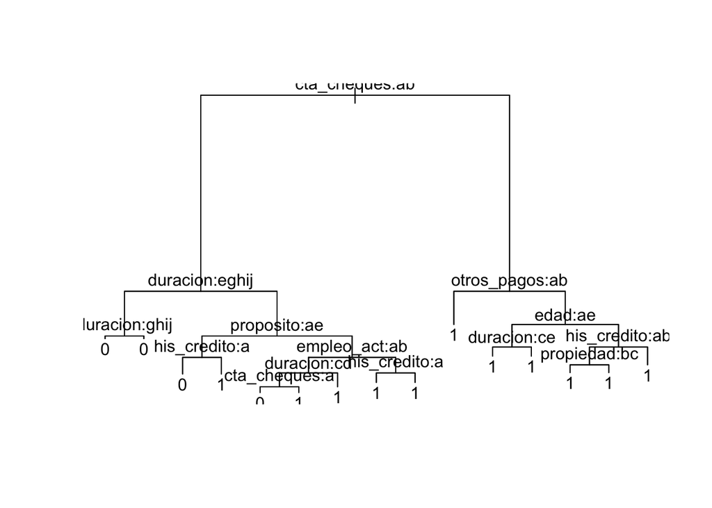

```r
plot(arbol)
text(arbol,digits=1,xpd =0.1)
```

```r
clases <- predict(arbol,german3[,-21],type="class")
APER <- sum(diag(table(clases,german3$default)))/1000
APER
```

```
## [1] 0.752
```

### Chi-Square Automatic Interaction detection CHAID

Otro método para clasificar con datos categóricos, basado en la prueba $\chi^2$ de bondad de ajuste. Si la respuesta tiene $r$ categorías, el método maximiza la estadística $\chi^2$ entre las $d$ categorías en la variable de respuesta y todas las posibles agrupaciones en las categorías de la variable predictora.

```r
library(CHAID)
chaidm1 <- chaid(default ~ ., data=german3, control = chaid_control(alpha2=0.1))
chaidm1
```

```
##
## Model formula:
## default ~ cta_cheques + duracion + his_credito + proposito +
##     monto + cta_ahorro + empleo_act + tasa_pagos + status_personal +
##     otros_deudores + resid_act + propiedad + edad + otros_pagos +
##     casa + no_creditos + tipo_trabajo + num_depen + telefono +
##     extranjero
##
## Fitted party:
## [1] root
## |   [2] cta_cheques in no_saldo
## |   |   [3] his_credito in pagados, retrasados
## |   |   |   [4] otros_deudores in ninguno
## |   |   |   |   [5] tasa_pagos in 1, 2: 1 (n = 53, err = 43.4%)
## |   |   |   |   [6] tasa_pagos in 3, 4
## |   |   |   |   |   [7] no_creditos in 1, 4: 0 (n = 107, err = 37.4%)
## |   |   |   |   |   [8] no_creditos in 2, 3: 0 (n = 21, err = 9.5%)
## |   |   |   [9] otros_deudores in alguno: 1 (n = 26, err = 30.8%)
## |   |   [10] his_credito in criticos: 1 (n = 67, err = 26.9%)
## |   [11] cta_cheques in saldo
## |   |   [12] monto in (232,6.31e+03], (6.31e+03,1.24e+04]
## |   |   |   [13] cta_ahorro in menos_100, de100a1000: 1 (n = 250, err = 38.4%)
## |   |   |   [14] cta_ahorro in mas_1000, nocuenta: 1 (n = 70, err = 15.7%)
## |   |   [15] monto in (1.24e+04,1.84e+04]: 0 (n = 12, err = 0.0%)
## |   [16] cta_cheques in nocuenta
## |   |   [17] otros_pagos in banco, tiendas
## |   |   |   [18] proposito in auto_nuevo, otros, educacion: 0 (n = 28, err = 50.0%)
## |   |   |   [19] proposito in auto_usado, hogar: 1 (n = 36, err = 13.9%)
## |   |   [20] otros_pagos in ninguno
## |   |   |   [21] his_credito in pagados
## |   |   |   |   [22] otros_deudores in ninguno
## |   |   |   |   |   [23] no_creditos in 1
## |   |   |   |   |   |   [24] status_personal in h_div_sol, h_cas_viud: 1 (n = 90, err = 2.2%)
## |   |   |   |   |   |   [25] status_personal in m_div_sep_cas: 1 (n = 44, err = 13.6%)
## |   |   |   |   |   [26] no_creditos in 2, 3, 4: 1 (n = 18, err = 27.8%)
## |   |   |   |   [27] otros_deudores in alguno: 1 (n = 12, err = 33.3%)
## |   |   |   [28] his_credito in retrasados: 1 (n = 32, err = 21.9%)
## |   |   |   [29] his_credito in criticos
## |   |   |   |   [30] monto in (232,6.31e+03]
## |   |   |   |   |   [31] proposito in auto_nuevo, auto_usado, otros, hogar: 1 (n = 112, err = 0.0%)
## |   |   |   |   |   [32] proposito in educacion: 1 (n = 10, err = 10.0%)
## |   |   |   |   [33] monto in (6.31e+03,1.24e+04], (1.24e+04,1.84e+04]: 1 (n = 12, err = 16.7%)
##
## Number of inner nodes:    15
## Number of terminal nodes: 18
```

[figure not shown]

```r
plot(chaidm1)
```

```r
clases <-predict(chaidm1,german3[,-21])
APER <- sum(diag(table(clases,german3$default)))/1000
APER
```

```
## [1] 0.756
```

```r
library(nnet)
library(devtools)
source_url('https://gist.githubusercontent.com/fawda123/7471137/raw/466c1474d0a505ff044412703516c34f1a4684a5/nnet_plot_update.r')
```

```
## SHA-1 hash of file is 74c80bd5ddbc17ab3ae5ece9c0ed9beb612e87ef
```

```r
nnetm1 <- nnet(default ~ ., data=german3, size=15)
nnetm1
```

```
## a 52-15-1 network with 811 weights
## inputs: cta_chequessaldo cta_chequesnocuenta duracion(10.8,17.6] duracion(17.6,24.4] duracion(24.4,31.2] duracion(31.2,38] duracion(38,44.8] duracion(44.8,51.6] duracion(51.6,58.4] duracion(58.4,65.2] duracion(65.2,72.1] his_creditoretrasados his_creditocriticos propositoauto_usado propositootros…
## output(s): default
## options were - entropy fitting
```

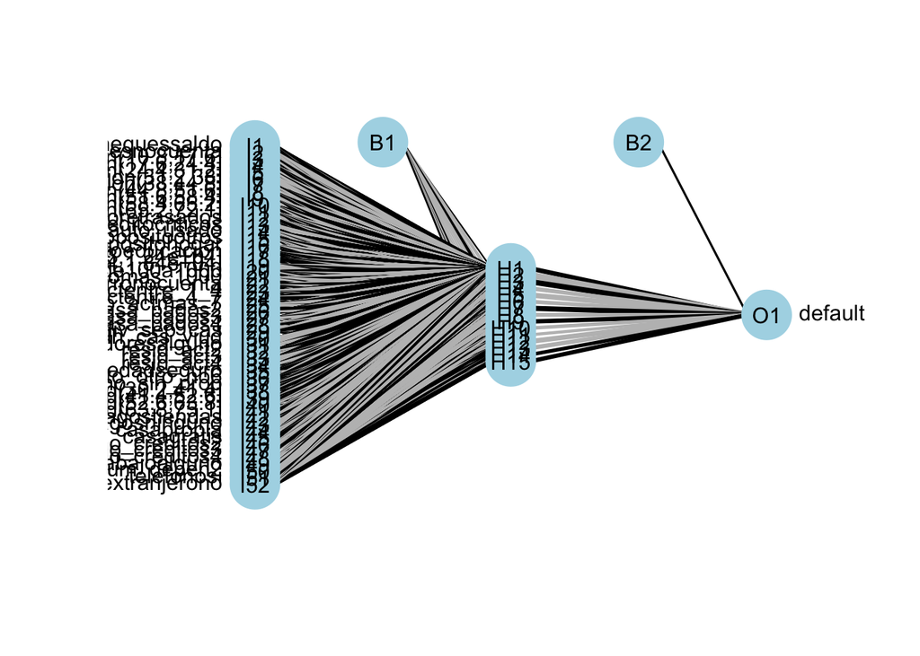

```r
plot.nnet(nnetm1)
```

```r
clases <- predict(nnetm1, german3[,-21], type = "class")
APER <- sum(diag(table(clases,german3$default )))/1000
APER
```

```
## [1] 1
```